# Assignment5

Andi Liao

2016年11月5日

# 1.

绘制salary的直方图，设定参数bins为20。

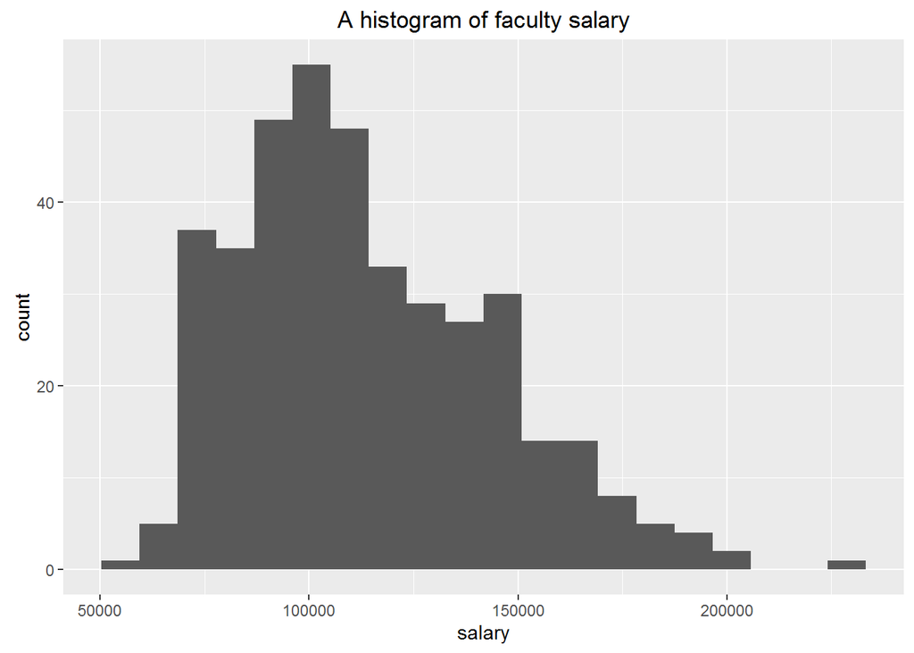

```r
library(ggplot2)
setwd("C:/Users/ThinkPad/Desktop/数据科学导论/data")
load("Salaries_692402902.RData")

ggplot(Salaries, aes(x=salary))+
  geom_histogram(bins=20)+
  labs(title = "A histogram of faculty salary")
```

# 2.

以years of service为x轴，salary为y轴，绘制散点图，并加上拟合曲线。

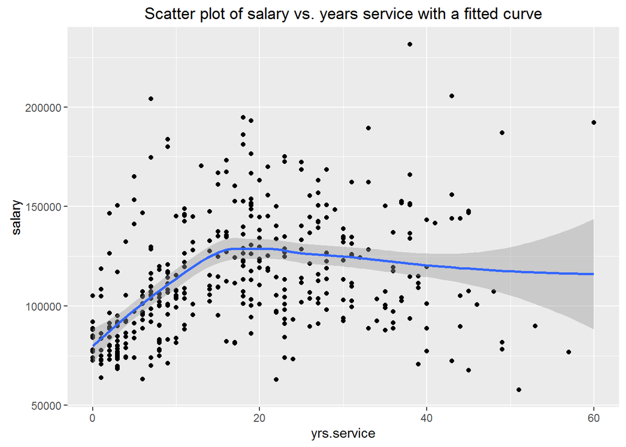

```r
ggplot(Salaries, aes(x = yrs.service, y = salary))+
  geom_point()+
  geom_smooth()+
  labs(title = "Scatter plot of salary vs. years service with a fitted curve")
```

# 3.

以rank为分类标准，绘制salary的箱线图，打上jitter point。

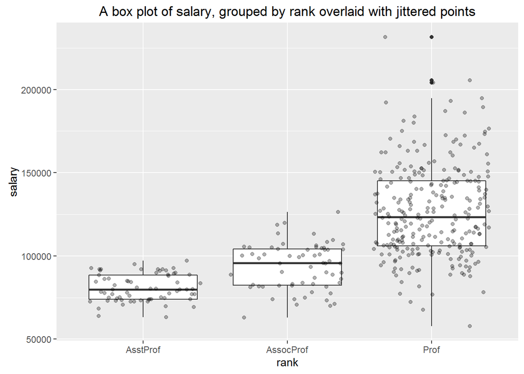

```r
ggplot(Salaries, aes(x = rank, y = salary))+geom_boxplot()+geom_jitter(alpha = 0.3)+labs(title = "A box plot of salary, grouped by rank overlaid with jittered points")
```

# 4.

以rank为分类标准，绘制salary的箱线图，加上violin plot。

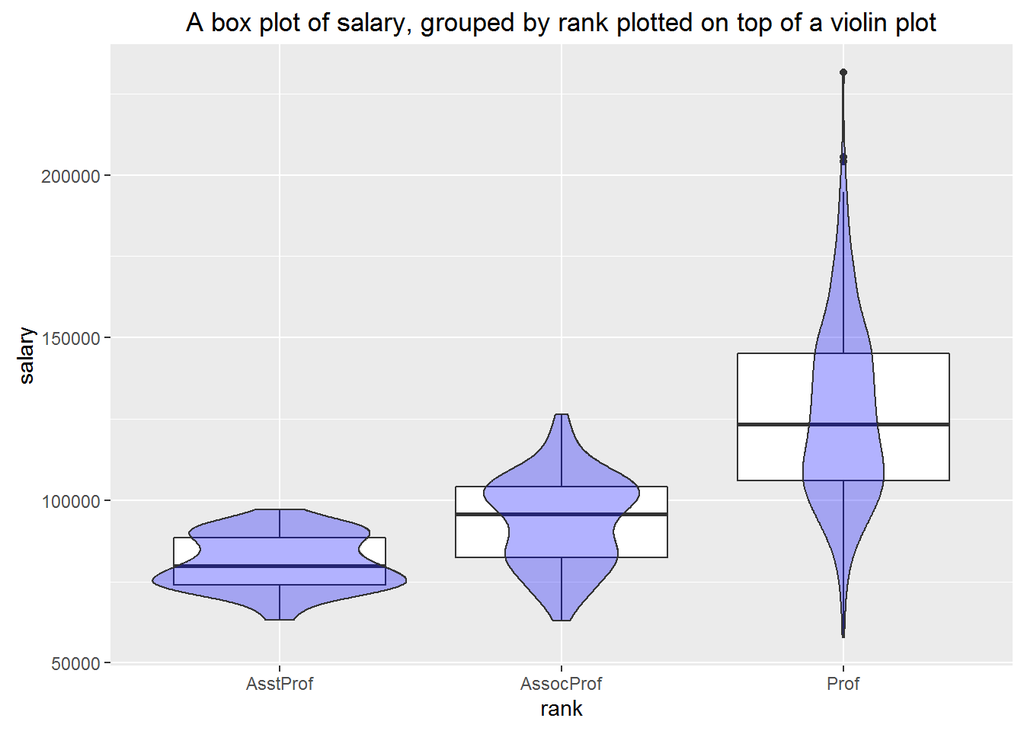

```r
ggplot(Salaries, aes(x = rank, y = salary))+
  geom_boxplot()+
  geom_violin( fill = "blue", alpha = 0.3)+
  labs(title = "A box plot of salary, grouped by rank plotted on top of a violin plot")
```

# 5.

以rank为分类标准，统计各个rank涵盖的人数，绘制条形图。

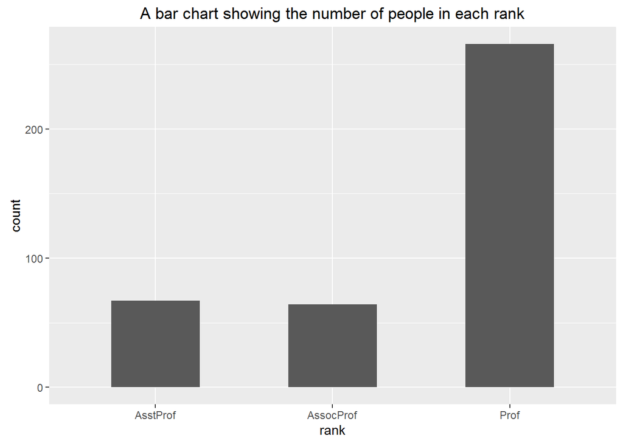

```r
ggplot(Salaries, aes(x = rank))+
  geom_bar(width = 0.5) +
  labs(title = "A bar chart showing the number of people in each rank")
```

# 6.

以rank为分类标准，统计各个rank的平均工资，绘制条形图。

```r
library(dplyr)
```

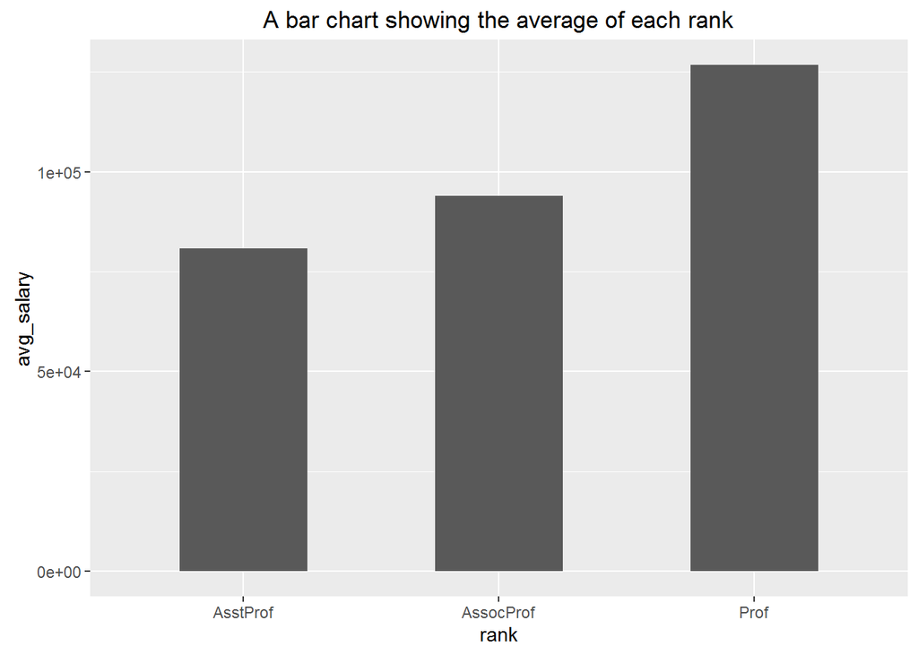

```r
temp1 = Salaries %>% group_by(rank) %>% summarize(avg_salary = mean(salary))
ggplot(temp1, aes(x = rank, y = avg_salary))+
  geom_bar(width = 0.5, stat = "identity") +
  labs(title = "A bar chart showing the average of each rank")
```

# 7.

以years of service为x轴，salary为y轴，rank为颜色标记，绘制散点图。

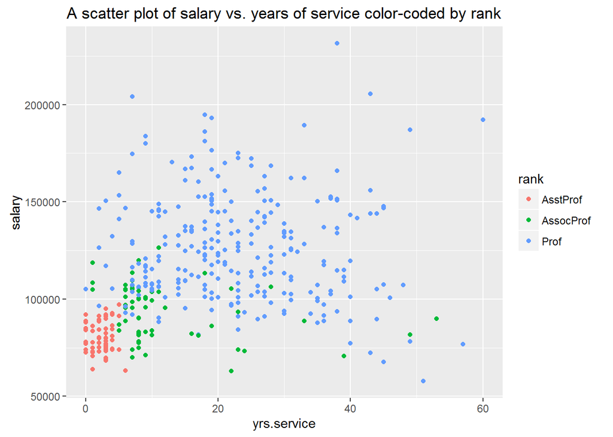

```r
ggplot(Salaries, aes(x = yrs.service, y = salary, color = rank))+
  geom_point()+
  labs(title="A scatter plot of salary vs. years of service color-coded by rank")
```

# 8.

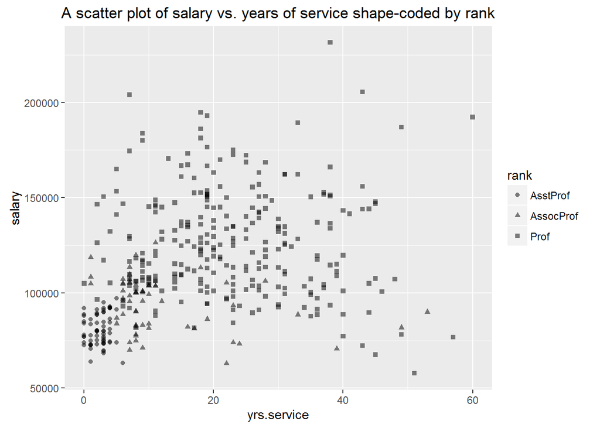

```r
ggplot(Salaries, aes(x = yrs.service, y = salary, shape = rank))+
  geom_point(alpha = 0.5)+
  labs(title="A scatter plot of salary vs. years of service shape-coded by rank")
```

# 9.

以rank和sex为分类标准，绘制salary的箱线图。

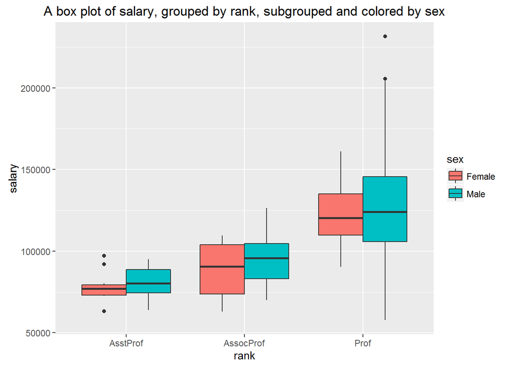

```r
ggplot(Salaries, aes(x = rank, y = salary, fill = sex))+
  geom_boxplot()+
  labs(title="A box plot of salary, grouped by rank, subgrouped and colored by sex")
```

# 10.

以rank为分类标准，以sex为jitter point上色标准，绘制salary的箱线图。

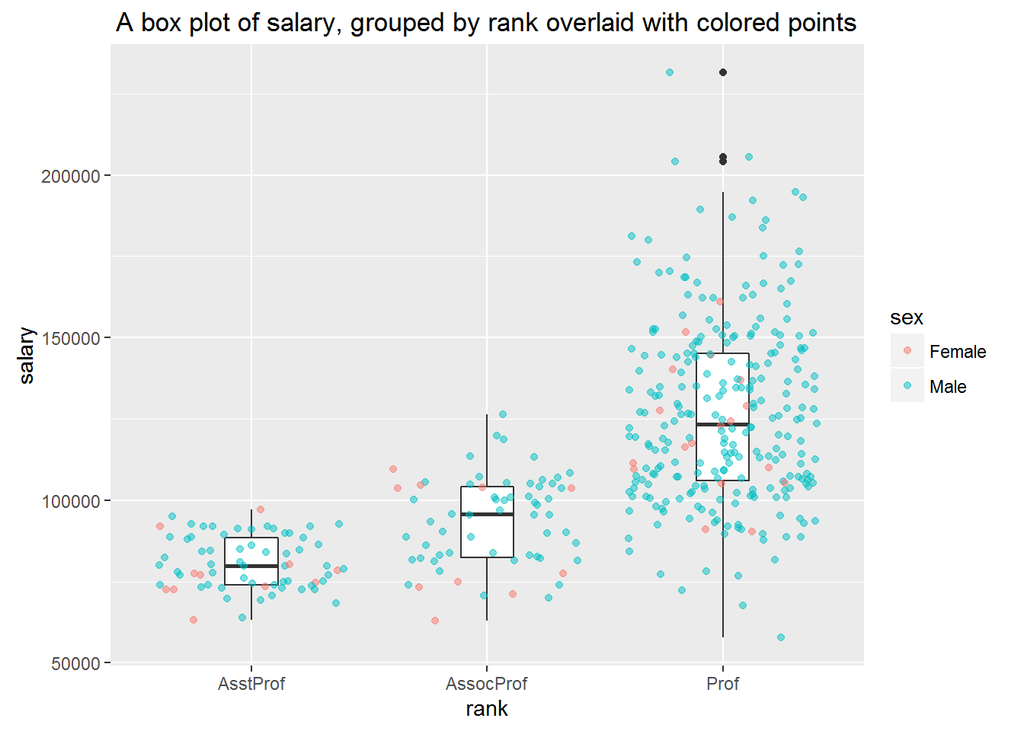

```r
ggplot(Salaries, aes(x = rank, y = salary))+
  geom_boxplot(width = 0.3)+
  geom_jitter(aes(color = sex), alpha = 0.5)+
  labs(title="A box plot of salary, grouped by rank overlaid with colored points")
```

# 11.

以rank为分类和上色标准，绘制salary的密度图。

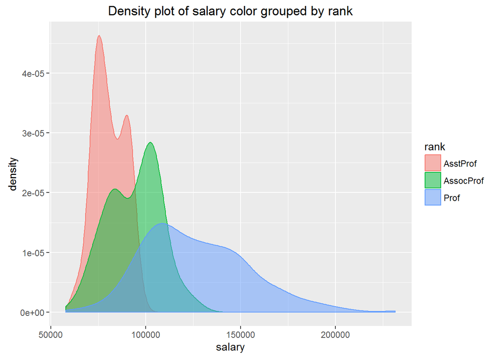

```r
ggplot(Salaries, aes(x = salary, color = rank, fill = rank))+
  geom_density(alpha = 0.5)+
  labs(title="Density plot of salary color grouped by rank")
```

# 12.

以sex为分类和上色标准，绘制salary的密度图。

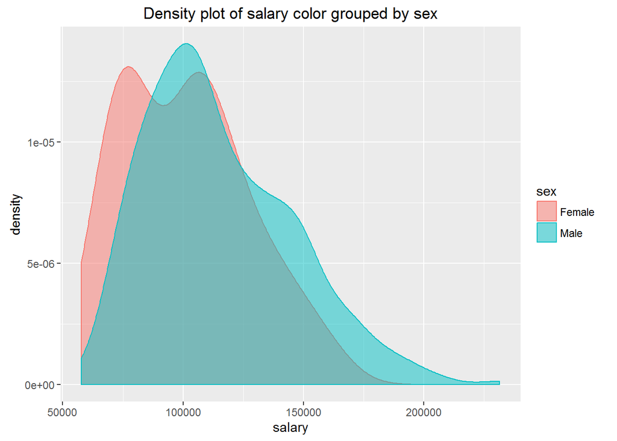

```r
ggplot(Salaries, aes(x = salary, color = sex, fill = sex))+
  geom_density(alpha = 0.5)+
  labs(title="Density plot of salary color grouped by sex")
```

# 13.

以rank和sex为分类标准，绘制每个rank和sex所对应的人数条形图。

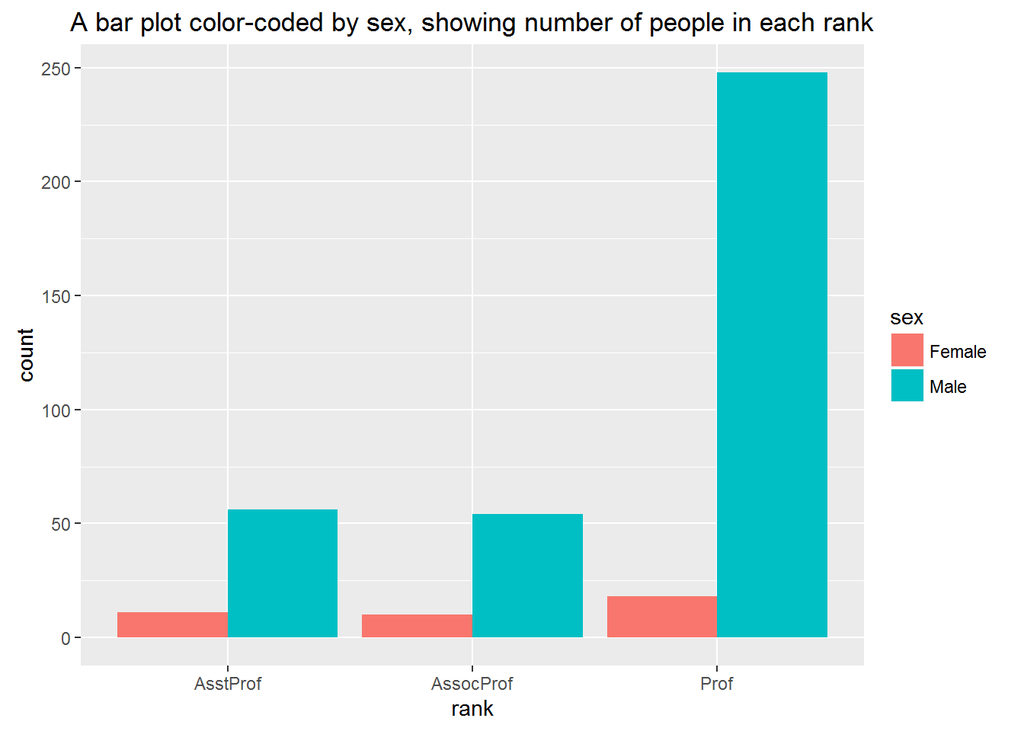

```r
ggplot(Salaries, aes(x = rank,fill = sex))+
  geom_bar(position = "dodge")+
  labs(title="A bar plot color-coded by sex, showing number of people in each rank")
```

# 14.

以rank和sex为分类标准，绘制每个rank和sex所对应的平均工资条形图。

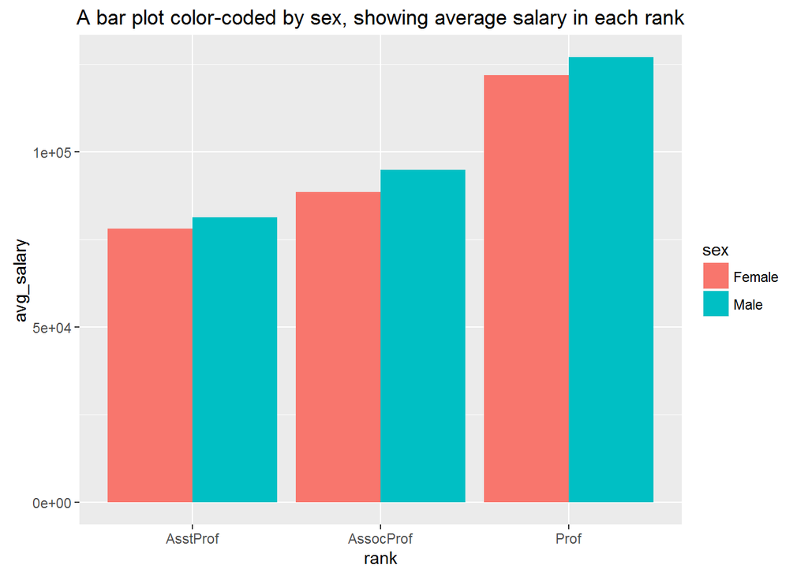

```r
temp2 = Salaries %>% group_by(sex, rank) %>% summarize(avg_salary = mean(salary))
ggplot(temp2, aes(x = rank, y = avg_salary,fill = sex))+
  geom_bar(stat = "identity", position = "dodge")+
  labs(title="A bar plot color-coded by sex, showing average salary in each rank")
```

# 15.

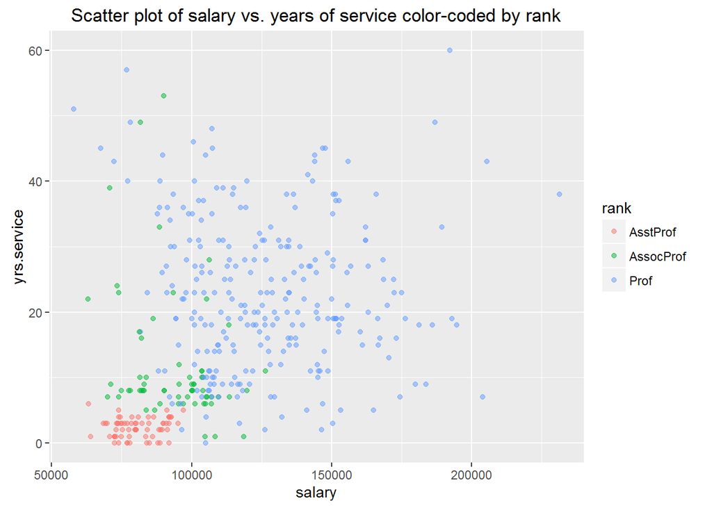

```r
ggplot(Salaries, aes(x= salary, y = yrs.service,color = rank))+
  geom_point(alpha = 0.5)+
  labs(title="Scatter plot of salary vs. years of service color-coded by rank")
```

# 16.

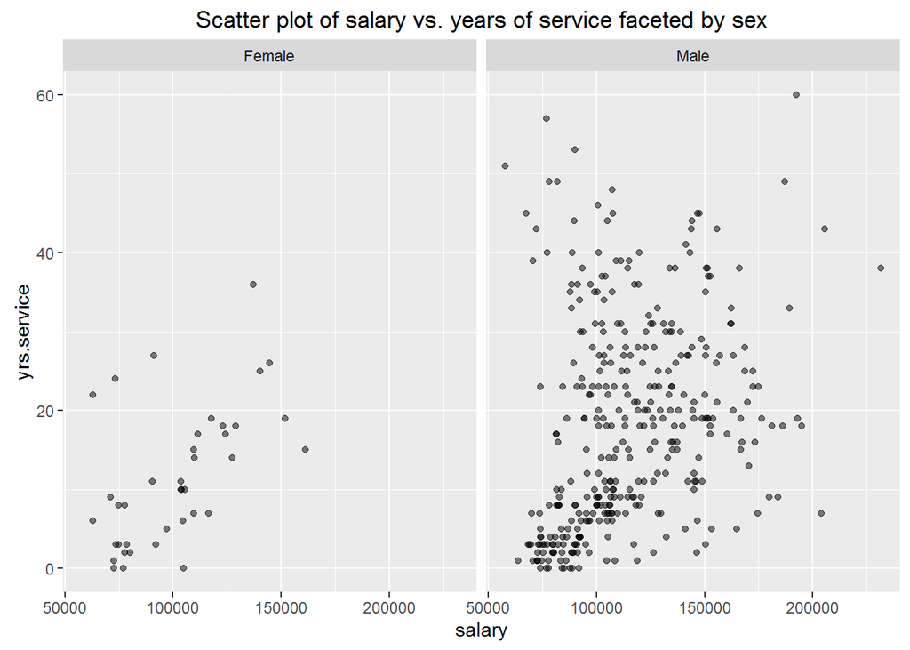

```r
ggplot(Salaries, aes(x= salary, y = yrs.service))+
  geom_point(alpha = 0.5)+
  facet_grid(.~sex)+
  labs(title="Scatter plot of salary vs. years of service faceted by sex")
```

# 17.

按照sex和rank分别绘制对应salary的密度图。

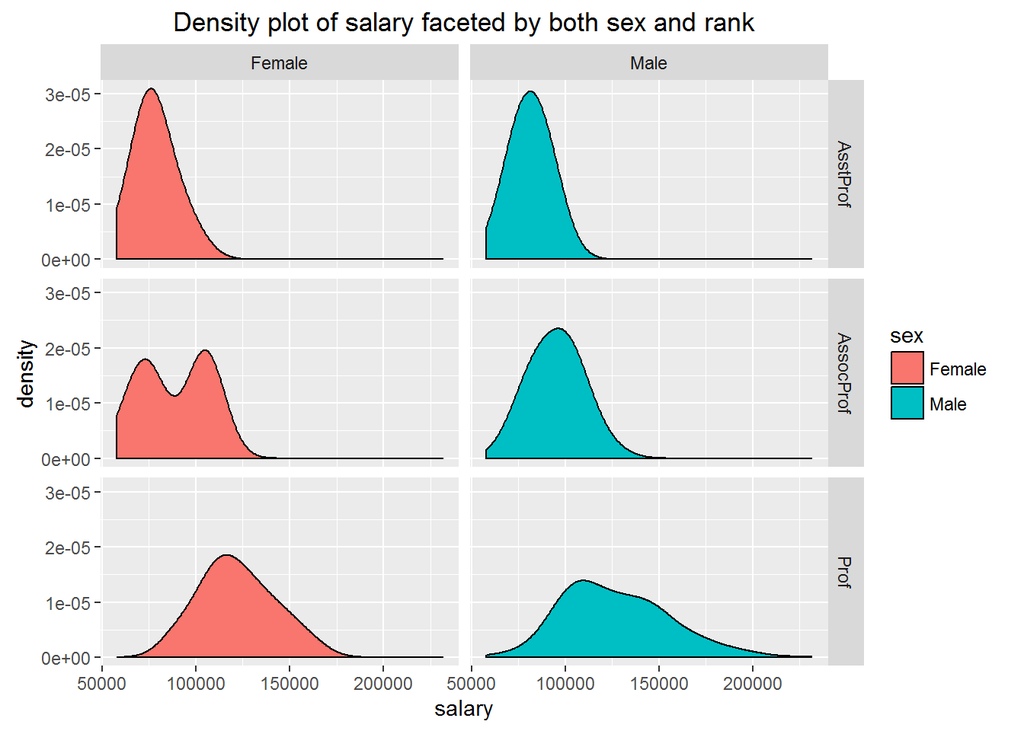

```r
ggplot(Salaries, aes(x = salary))+
  geom_density(aes(fill = sex), bw = 10000)+
  facet_grid(rank~sex)+
  labs(title="Density plot of salary faceted by both sex and rank")
```

# 18.

按照sex分别绘制各个rank的salary密度图。

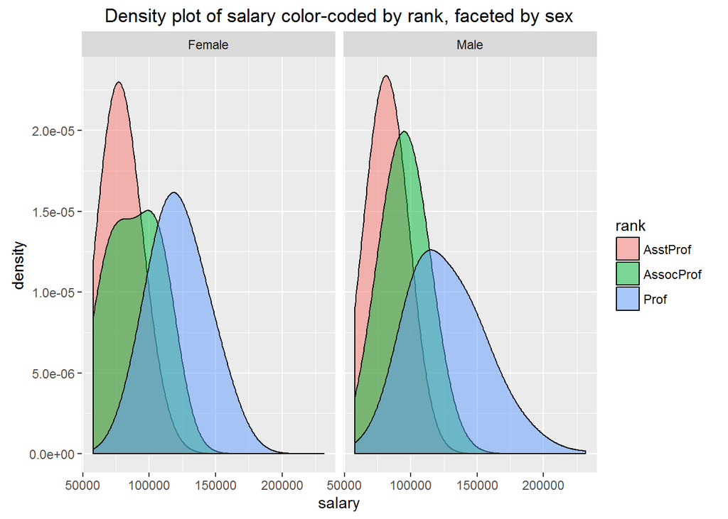

```r
ggplot(Salaries, aes(x = salary))+
  geom_density(aes(fill = rank), bw = 15000, alpha = 0.5)+
  facet_grid(.~sex)+
  labs(title="Density plot of salary color-coded by rank, faceted by sex")
```

# 19.

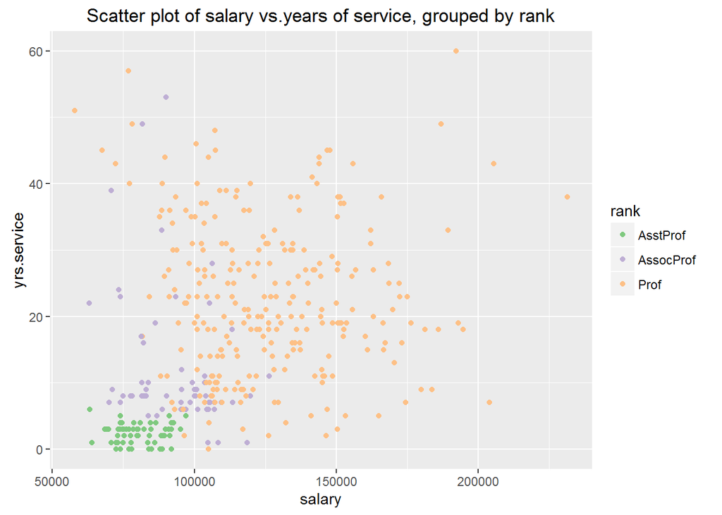

```r
ggplot(Salaries, aes(x= salary, y = yrs.service, color = rank))+
  geom_point()+
  scale_colour_brewer(palette = "Accent")+
  labs(title="Scatter plot of salary vs.years of service, grouped by rank")
```

# 20.

按照rank绘制salary的密度图，改变颜色范围。

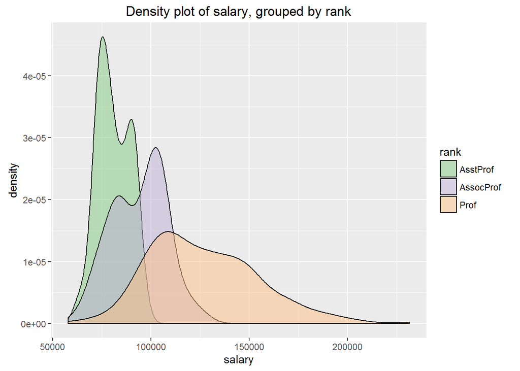

```r
ggplot(Salaries,aes(x = salary, fill = rank))+
  geom_density(alpha =0.5)+
  scale_fill_brewer(palette = "Accent")+
  labs(title="Density plot of salary, grouped by rank")
```

# 21.

按照sex和rank分别绘制对应salary的箱线图，改变X轴标签。

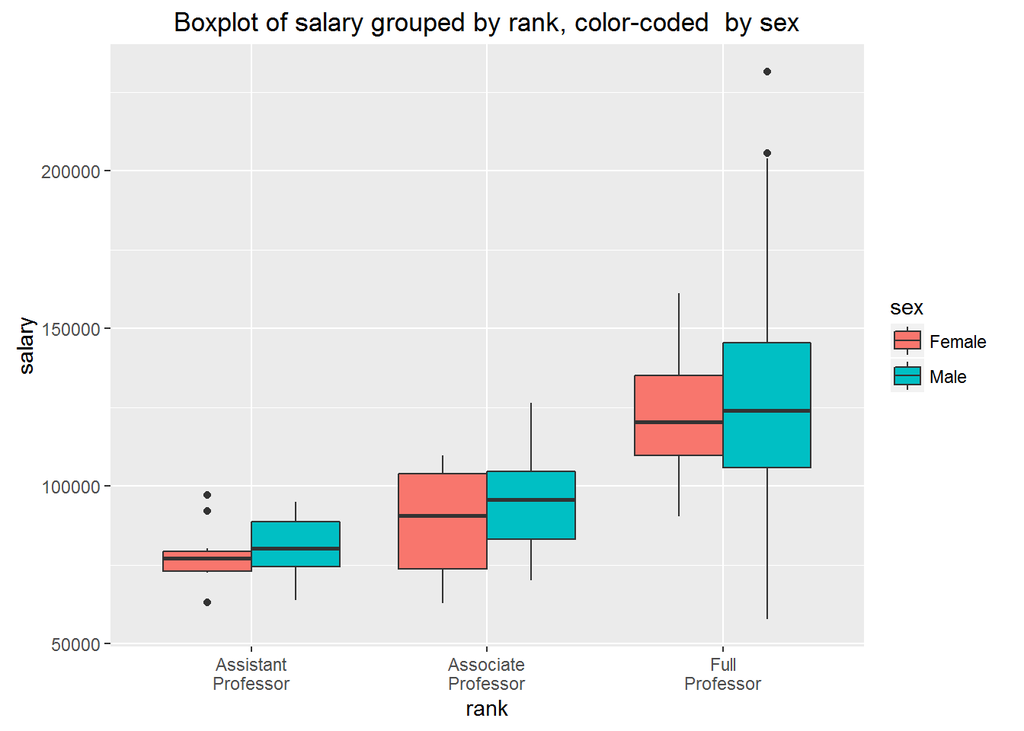

```r
ggplot(Salaries, aes(x = rank, y =salary, fill =sex))+
  geom_boxplot()+
  scale_x_discrete(breaks =c("AsstProf","AssocProf","Prof"), labels=c("Assistant\nProfessor","Associate\nProfessor","Full\nProfessor"))+
  labs(title="Boxplot of salary grouped by rank, color-coded  by sex")
```

# 22.

按照sex和rank分别绘制对应salary的箱线图，改变y轴标签。

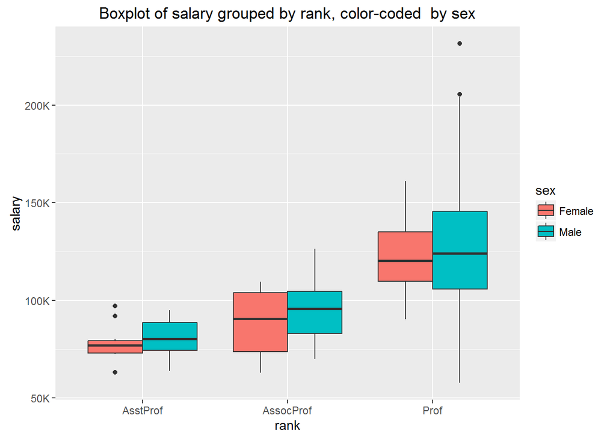

```r
ggplot(Salaries, aes(x = rank, y =salary, fill =sex))+
  geom_boxplot()+
  scale_y_continuous(breaks=c(50000,100000,150000,200000),labels=c("50K","100K","150K","200K"))+
  labs(title="Boxplot of salary grouped by rank, color-coded  by sex")
```

# 23.

按照sex和rank分别绘制对应salary的箱线图，改变y轴数值。

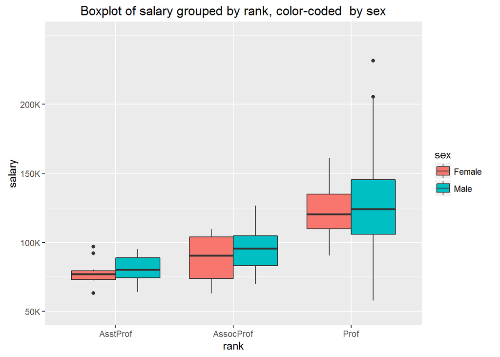

```r
ggplot(Salaries, aes(x = rank, y =salary, fill =sex))+
  geom_boxplot()+
  scale_y_continuous(breaks=c(50000,100000,150000,200000),labels=c("50K","100K","150K","200K"),limits = c(50000,250000))+
  labs(title="Boxplot of salary grouped by rank, color-coded  by sex")
```

# 24.

按照sex和rank分别绘制对应salary的箱线图，改变布局及图例。

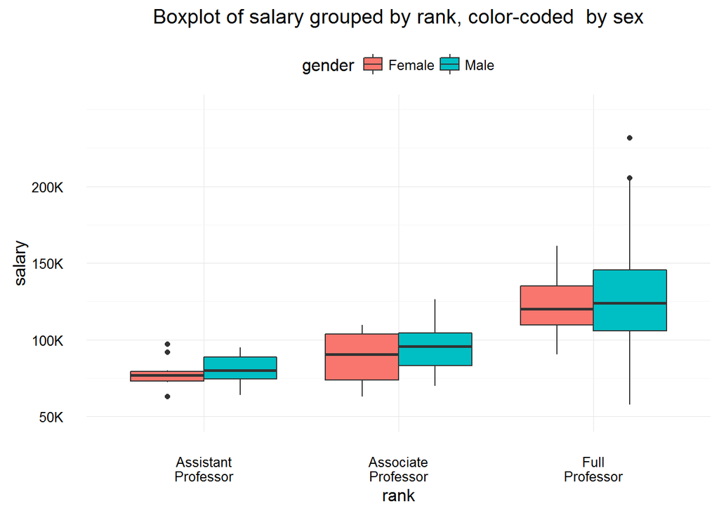

```r
ggplot(Salaries, aes(x = rank, y =salary, fill =sex))+
  geom_boxplot()+
  scale_x_discrete(breaks =c("AsstProf","AssocProf","Prof"), labels=c("Assistant\nProfessor","Associate\nProfessor","Full\nProfessor"))+
  scale_y_continuous(breaks=c(50000,100000,150000,200000),labels=c("50K","100K","150K","200K"),limits = c(50000,250000))+
  theme_minimal()+
  labs(fill="gender")+
  theme(legend.position="top",legend.direction="horizontal")+
  labs(title="Boxplot of salary grouped by rank, color-coded  by sex")
```